# Chapter 4: Interactions in Multiple Regression: Models for Moderation

Statistical Modelling Methods: A Guide for the Social and Behavioural Sciences (2nd ed.)

Author

David Flora & Miranda Too

# Chapter 4 Textbook Content

## Loading R Packages

```r
library(car)
library(psych)
library(misty)
```

## Importing Alcohol Use Data

In previous chapters, we imported .txt data files with the `read.table()` function, which assumes white space as the field separator or *deliminator* (i.e., the character that separates the columns). These files can also be imported with the `read.csv()` and `read.delim()` functions. The `read.csv()` function assumes that commas are the deliminator, and the `read.delim()` function assumes that tabs are the deliminator. If your data uses a different deliminator than the function specifies, the columns will be specified incorrectly, likely with all data appearing in one column.

To rectify this issue, you can add an argument specifying the deliminator. In this case, the separator in the `drink.txt` data file is a white space character (e.g., one or more spaces), so we have added the argument `sep=""`, to indicate this separator.

```r
drink <- read.delim("drink.txt", sep="")

#If you're interested to see the result of an incorrectly specified deliminator, you can remove the #s and run the next two lines

#drink_test <- read.delim("drink.txt")
#head(drink_test)

str(drink)
```

```
'data.frame':   165 obs. of  4 variables:
 $ coa   : int  1 1 1 1 1 1 1 1 1 1 ...
 $ alcuse: num  1.219 0.469 0 0 0.469 ...
 $ ext   : num  0.0833 0.3333 0.4167 0.5833 0.0833 ...
 $ numalc: int  1 1 1 1 1 1 2 1 1 1 ...
```

```r
#Notice that the coa and numalc variables are of type int (i.e., integer). But coa is binary and numalc has only three categories:

table(drink$coa)
```

```
 0  1
75 90
```

```r
table(drink$numalc)
```

```
 0  1  2
75 81  9
```

## Interactions with a Binary Moderator - Research Example

Flora et al. (2007) examined how parental alcoholism moderated the relation between an adolescent’s level of externalizing behaviour and subsequent heavy alcohol use.

### Table 4.1 - Means, Standard Deviations, and Correlations

The binary ‘parent’ variable referred to in the text is represented with the `coa` variable in the `drink` data frame. It’s a little strange to get these descriptive stats for a binary variable, but because `coa` is coded as 0 (no alcoholic parents) or 1 (at least one alcoholic parent), its mean gives the proportion of the sample with an alcoholic parent, and correlations between `coa` and the other variables are a special type of Pearson product-moment correlation known as a *point-biserial correlation*.

```r
#Means and SD
descript(drink$ext, print = c("m", "sd")) # Focal predictor, externalizing
```

```
 Descriptive Statistics

     M   SD
  0.56 0.44
```

```r
descript(drink$coa, print = c("m", "sd")) # Moderator, parental alcoholism
```

```
 Descriptive Statistics

     M   SD
  0.55 0.50
```

```r
descript(drink$alcuse, print = c("m", "sd")) # Outcome, alcohol use
```

```
 Descriptive Statistics

     M   SD
  0.36 0.67
```

```r
#Correlations
#Selecting only the three variables used in Table 4.1
cor.matrix(drink[,c("coa","ext","alcuse")])
```

```
 Pearson Product-Moment Correlation Coefficient

          coa  ext alcuse
  coa
  ext    0.21
  alcuse 0.29 0.34

 Note. n = 165, No missing data
```

### Figure 4.1 - Plotting Externalizing-Alcohol Use Relationship by Sub-Population

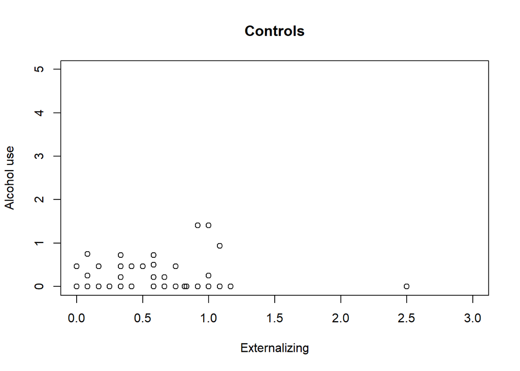

```r
#Creating a data frame with only participants who ARE NOT children of alcoholics (i.e., coa == 0)
controls <- subset(drink, coa==0)

#Creating a data frame with only participants who ARE children of alcoholics (i.e., coa == 1)
coas <- subset(drink, coa==1)

#Plot relationship between externalizing and alcohol use for children of non-alcoholics
plot(controls$alcuse~controls$ext, pch=1,
     ylab='Alcohol use',xlab='Externalizing',
     main='Controls',
     xlim=c(0,3), ylim=c(0,5))
```

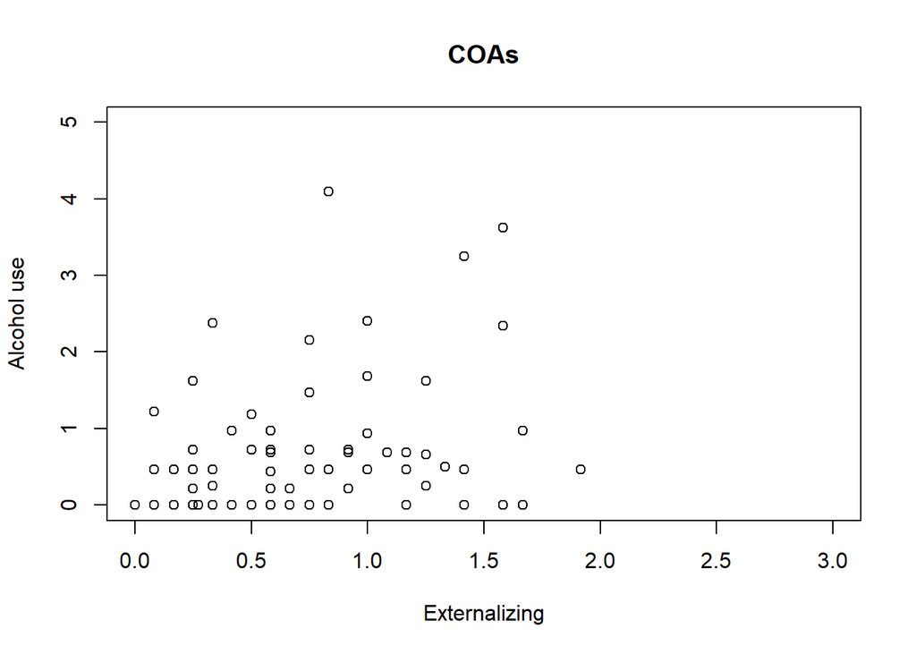

```r
#Plot relationship between externalizing and alcohol use for children of alcoholics
plot(coas$alcuse~coas$ext, pch=1,
     ylab='Alcohol use',xlab='Externalizing',
     main='COAs',
     xlim=c(0,3), ylim=c(0,5))
```

## Model Specification and Interpretation with a Binary Moderator

### Table 4.2 - Applying model in Equation 4.1

Here we specify a model regressing alcohol use on alcoholic parents (binary), externalizing, and their interaction.

```r
# Modeling Alcohol Use as function of externalizing levels, family alcohol use/history
mod1 <- lm(alcuse~coa+ext+(ext*coa), data=drink)
summary(mod1)
```

```
Call:
lm(formula = alcuse ~ coa + ext + (ext * coa), data = drink)

Residuals:
    Min      1Q  Median      3Q     Max
-1.2206 -0.2731 -0.1382  0.1373  3.4305

Coefficients:
            Estimate Std. Error t value Pr(>|t|)
(Intercept) 0.104262   0.106595   0.978   0.3295
coa         0.001682   0.155166   0.011   0.9914
ext         0.101702   0.172869   0.588   0.5571
coa:ext     0.567081   0.224159   2.530   0.0124 *
---
Signif. codes:  0 '***' 0.001 '**' 0.01 '*' 0.05 '.' 0.1 ' ' 1

Residual standard error: 0.6114 on 161 degrees of freedom
Multiple R-squared:  0.1943,    Adjusted R-squared:  0.1792
F-statistic: 12.94 on 3 and 161 DF,  p-value: 1.291e-07
```

```r
#The output shows that the interaction effect is significant (p = .0124)
#The slope estimate for the ext variable is a simple-slope estimate indicating that each point higher on ext is associated with a 0.101 higher alcuse score AMONG CONTROL participants (among those with coa = 0).

confint(mod1)
```

```
                 2.5 %    97.5 %
(Intercept) -0.1062430 0.3147663
coa         -0.3047413 0.3081058
ext         -0.2396821 0.4430858
coa:ext      0.1244105 1.0097520
```

## Probing an interaction with simple slope analysis

### Figure 4.2 - plotting the relationship between alcohol use and externalizing by parental alcoholism

The `scatterplot()` function in the `car` package can plot separate relationships between a focal and an outcome by a grouping variable. To specify the grouping variable, use the `|` operator followed by the name of the grouping variable (in this case, we want to group by whether participants are children of alcoholics, `coa`) after the focal predictor in your model formula.

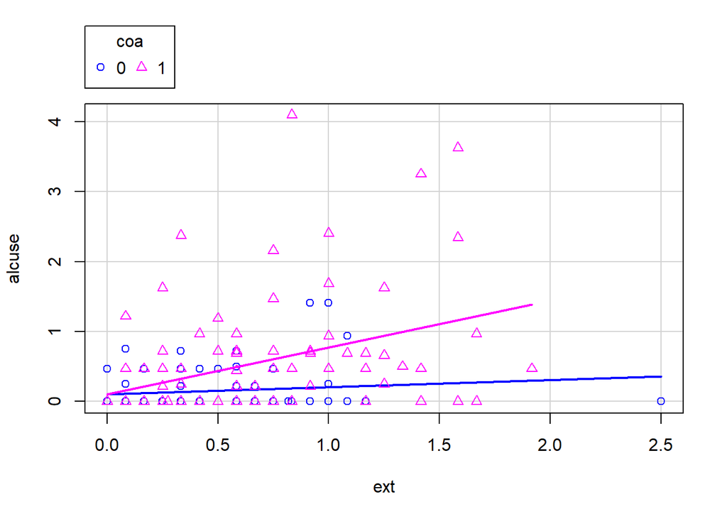

```r
#Default scatterplot
scatterplot(alcuse ~ ext|coa, smooth=F, data=drink)
```

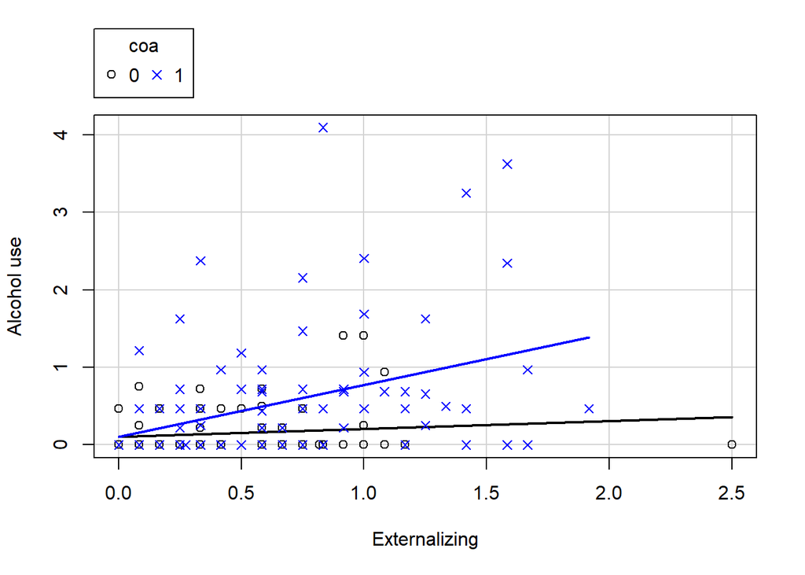

```r
#Scatterplot with modified aesthetics (labels, colour changes)
scatterplot(alcuse~ext|coa, smooth=F,
            pch=c(1,4), col=c('black','blue'), lty=c(1,2),ylab='Alcohol use',xlab='Externalizing', data=drink)
```

### Table 4.3 - Recoded Binary Children of Alcoholics Model

```r
#Create a new reverse coded version of initial COA variable called "ncoa." Here we are taking the absolute value of (coa - 1), so that 0 will become 1 and 1 will become 0:
drink$ncoa <- abs(drink$coa-1)

# Next we will re-estimate the earlier model using the recoded variable.
mod1r <- lm(alcuse~ncoa+ext+(ncoa*ext), data=drink)
summary(mod1r)
```

```
Call:
lm(formula = alcuse ~ ncoa + ext + (ncoa * ext), data = drink)

Residuals:
    Min      1Q  Median      3Q     Max
-1.2206 -0.2731 -0.1382  0.1373  3.4305

Coefficients:
             Estimate Std. Error t value Pr(>|t|)
(Intercept)  0.105944   0.112757   0.940   0.3488
ncoa        -0.001682   0.155166  -0.011   0.9914
ext          0.668783   0.142700   4.687 5.88e-06 ***
ncoa:ext    -0.567081   0.224159  -2.530   0.0124 *
---
Signif. codes:  0 '***' 0.001 '**' 0.01 '*' 0.05 '.' 0.1 ' ' 1

Residual standard error: 0.6114 on 161 degrees of freedom
Multiple R-squared:  0.1943,    Adjusted R-squared:  0.1792
F-statistic: 12.94 on 3 and 161 DF,  p-value: 1.291e-07
```

```r
#Now the slope estimate for ext is a simple-slope estimate indicating that each point higher on ext is associated with a 0.668 higher alcuse score AMONG COA participants (among those with ncoa = 0, who are the participants who had coa = 1).

confint(mod1r)
```

```
                 2.5 %     97.5 %
(Intercept) -0.1167289  0.3286167
ncoa        -0.3081058  0.3047413
ext          0.3869776  0.9505886
ncoa:ext    -1.0097520 -0.1244105
```

### Figure 4.3 Residuals vs. Predicted Values for alcohol use regressed on parental alcoholism, externalizing, and their interaction

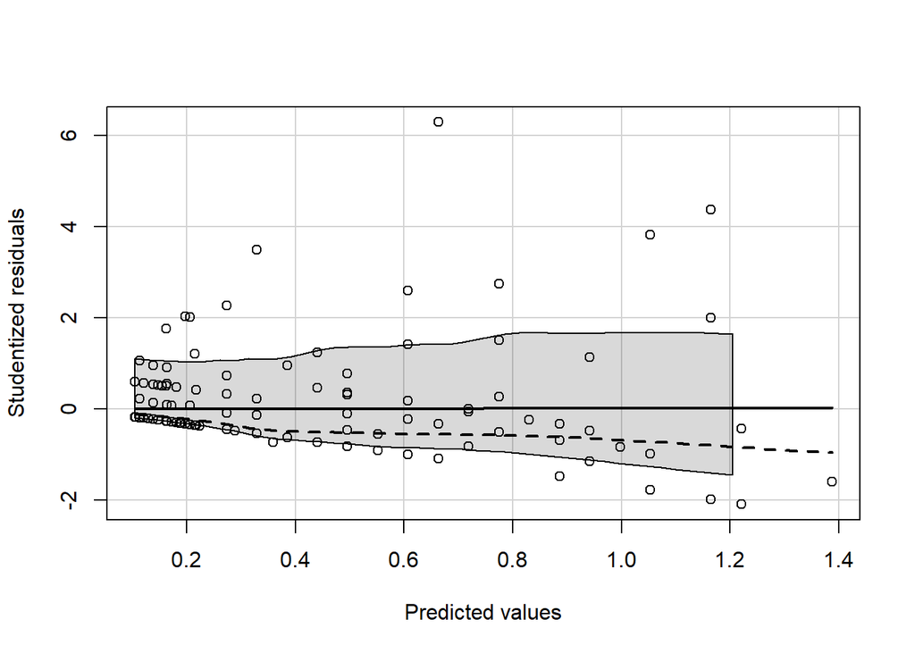

```r
scatterplot(rstudent(mod1)~fitted(mod1), boxplots=F, ylab='Studentized residuals',
            xlab='Predicted values', col='black')
```

## Interactions with a multi-category moderator

The variable `numalc` represents the number of alcoholic parents (no alcoholic parents, 1 alcoholic parent, or 2 alcoholic parents). We can use the `table()` function to examine frequencies.

```r
table(drink$numalc)
```

```
 0  1  2
75 81  9
```

```r
#n=75 participants have 0 alcoholic parents, n=81 participants have 1 alcoholic parent, and n = 9 participants have 2 alcoholic parents
```

As explained in Chapter 3, we can represent a 3-category independent variable using two dummy variables. If we specify `numalc` as a factor-type variable, R will automatically represent `numalc` with two dummy variables, using 0 (the lowest value) as the reference category. Then, we can estimate a linear model with an interaction between `numalc` and `ext`, and R will automatically include interaction terms between each dummy variable and `ext`:

```r
#Convert numalc to a factor:
drink$numalc <- factor(drink$numalc)

#Then estimate the model with an interaction between ext and numalc:
mod2 <- lm(alcuse ~ numalc + ext + numalc*ext, data=drink)
summary(mod2)
```

```
Call:
lm(formula = alcuse ~ numalc + ext + numalc * ext, data = drink)

Residuals:
    Min      1Q  Median      3Q     Max
-1.2024 -0.2254 -0.1297  0.1373  2.9554

Coefficients:
            Estimate Std. Error t value Pr(>|t|)
(Intercept)  0.10426    0.10572   0.986    0.326
numalc1     -0.04766    0.15840  -0.301    0.764
numalc2      0.27294    0.38020   0.718    0.474
ext          0.10170    0.17145   0.593    0.554
numalc1:ext  0.57359    0.22572   2.541    0.012 *
numalc2:ext  0.81166    0.58016   1.399    0.164
---
Signif. codes:  0 '***' 0.001 '**' 0.01 '*' 0.05 '.' 0.1 ' ' 1

Residual standard error: 0.6064 on 159 degrees of freedom
Multiple R-squared:  0.2172,    Adjusted R-squared:  0.1926
F-statistic: 8.826 on 5 and 159 DF,  p-value: 2.063e-07
```

```r
#Now, the slope estimate for ext represents the simple-slope ext effect among those with 0 alcoholic parents (the reference category for numalc):
#Each point higher on ext is associated with a 0.101 higher alcuse score among those with 0 alcoholic parents.
```

Next, we can probe the interaction between `ext` and `numalc` with a simple-slope analysis by changing the reference category for the `numalc` dummy variables using the `relevel()` function:

```r
#Change the reference category to be 1 alcoholic parent:
drink$numalc <- relevel(drink$numalc, ref = '1')
```

After changing the reference category, re-estimate the model:

```r
mod2 <- lm(alcuse ~ numalc + ext + numalc*ext, data=drink)
summary(mod2)
```

```
Call:
lm(formula = alcuse ~ numalc + ext + numalc * ext, data = drink)

Residuals:
    Min      1Q  Median      3Q     Max
-1.2024 -0.2254 -0.1297  0.1373  2.9554

Coefficients:
            Estimate Std. Error t value Pr(>|t|)
(Intercept)  0.05660    0.11795   0.480    0.632
numalc0      0.04766    0.15840   0.301    0.764
numalc2      0.32060    0.38378   0.835    0.405
ext          0.67529    0.14681   4.600 8.59e-06 ***
numalc0:ext -0.57359    0.22572  -2.541    0.012 *
numalc2:ext  0.23807    0.57336   0.415    0.679
---
Signif. codes:  0 '***' 0.001 '**' 0.01 '*' 0.05 '.' 0.1 ' ' 1

Residual standard error: 0.6064 on 159 degrees of freedom
Multiple R-squared:  0.2172,    Adjusted R-squared:  0.1926
F-statistic: 8.826 on 5 and 159 DF,  p-value: 2.063e-07
```

```r
#Now, the slope estimate for ext represents the simple-slope ext effect among those with 1 alcoholic parent (the new reference category for numalc):
#Each point higher on ext is associated with a 0.675 higher alcuse score among those with 1 alcoholic parent.
```

Finally, we can change the reference category to be 2 alcoholic parents and re-estimate the model:

```r
drink$numalc <- relevel(drink$numalc, ref = '2')
mod2 <- lm(alcuse ~ numalc + ext + numalc*ext, data=drink)
summary(mod2)
```

```
Call:
lm(formula = alcuse ~ numalc + ext + numalc * ext, data = drink)

Residuals:
    Min      1Q  Median      3Q     Max
-1.2024 -0.2254 -0.1297  0.1373  2.9554

Coefficients:
            Estimate Std. Error t value Pr(>|t|)
(Intercept)   0.3772     0.3652   1.033    0.303
numalc1      -0.3206     0.3838  -0.835    0.405
numalc0      -0.2729     0.3802  -0.718    0.474
ext           0.9134     0.5542   1.648    0.101
numalc1:ext  -0.2381     0.5734  -0.415    0.679
numalc0:ext  -0.8117     0.5802  -1.399    0.164

Residual standard error: 0.6064 on 159 degrees of freedom
Multiple R-squared:  0.2172,    Adjusted R-squared:  0.1926
F-statistic: 8.826 on 5 and 159 DF,  p-value: 2.063e-07
```

```r
#Now, the slope estimate for ext represents the simple-slope ext effect among those with 2 alcoholic parents (the new reference category for numalc):
#Each point higher on ext is associated with a 0.913 higher alcuse score among those with 2 alcoholic parents.
```

## Interactions with a Continuous Moderator

In this second research example, we are exploring the hypothesis that perceived social support (`support`) buffers, or moderates, the relationship between daily hassles (`hassles`) and psychological symptoms (`symptoms`).

```r
hass <- read.delim("HASSLESNA.txt")

str(hass)
```

```
'data.frame':   56 obs. of  3 variables:
 $ hassles : int  16 27 42 45 49 65 68 64 126 54 ...
 $ support : int  23 36 34 34 32 35 34 31 45 25 ...
 $ symptoms: int  80 64 77 78 62 86 106 66 118 86 ...
```

### Table 4.4 - Means, Standard Deviations, and Correlations

```r
descript(hass$hassles, print=c("m","sd")) # Focal predictor
```

```
 Descriptive Statistics

       M     SD
  170.20 124.34
```

```r
descript(hass$support, print=c("m","sd")) # Moderator
```

```
 Descriptive Statistics

      M   SD
  28.96 8.16
```

```r
descript(hass$symptoms, print=c("m","sd")) # Outcome
```

```
 Descriptive Statistics

      M    SD
  90.43 21.01
```

```r
cor.matrix(hass)
```

```
 Pearson Product-Moment Correlation Coefficient

           hassles support symptoms
  hassles
  support    -0.17
  symptoms    0.58   -0.13

 Note. n = 56, No missing data
```

### Figure 4.4: Scatterplot Matrix of Hassles, Symptoms, and Support

The `car` package has a handy `scatterplotMatrix` function:

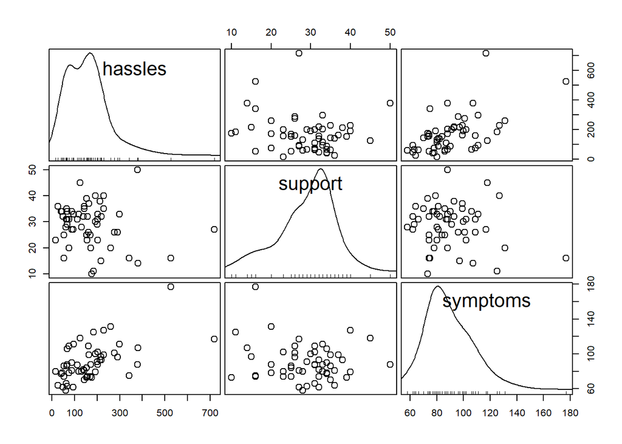

```r
scatterplotMatrix(hass, smooth=F, col='black', pch=21, diagonal='histogram',
                  cex=1.5,gap = 0.4, regLine = F)
```

### Table 4.5: Estimating model of symptoms regressed on hassles, support, and their interaction

```r
sympmod1 <- lm(symptoms~hassles+support+(hassles*support), data=hass)
summary(sympmod1)
```

```
Call:
lm(formula = symptoms ~ hassles + support + (hassles * support),
    data = hass)

Residuals:
    Min      1Q  Median      3Q     Max
-38.734 -13.379  -0.444   8.689  35.523

Coefficients:
                 Estimate Std. Error t value Pr(>|t|)
(Intercept)     45.750822  17.371529   2.634 0.011099 *
hassles          0.232643   0.066214   3.514 0.000925 ***
support          1.008385   0.588870   1.712 0.092780 .
hassles:support -0.005065   0.002363  -2.144 0.036767 *
---
Signif. codes:  0 '***' 0.001 '**' 0.01 '*' 0.05 '.' 0.1 ' ' 1

Residual standard error: 16.89 on 52 degrees of freedom
Multiple R-squared:  0.3885,    Adjusted R-squared:  0.3532
F-statistic: 11.01 on 3 and 52 DF,  p-value: 1.046e-05
```

```r
#The results indicate that the interaction is significant (p = .036767), but the estimate for hassles (the focal predictor) is the simple-slope effect AMONG THOSE WITH SUPPORT = 0.
#Therefore, it is better to get different simple-slope estimates after centering the support variable.
```

### Table 4.6: Model Estimated with 25th Percentile Centered Value of Support

```r
#We can use the summary function to find the value of the 25th percentile/1st quartile of support
summary(hass$support)
```

```
   Min. 1st Qu.  Median    Mean 3rd Qu.    Max.
  10.00   25.00   31.00   28.96   34.00   50.00
```

```r
#Next, we create a new support variable called "suppL," which is the support variable centered around the 25th percentile
hass$suppL <- hass$support - 25

#Then, we estimate the model with the 25th percentile centered support variable
sympmodL <- lm(symptoms~hassles+suppL+(hassles*suppL), data = hass)
summary(sympmodL)
```

```
Call:
lm(formula = symptoms ~ hassles + suppL + (hassles * suppL),
    data = hass)

Residuals:
    Min      1Q  Median      3Q     Max
-38.734 -13.379  -0.444   8.689  35.523

Coefficients:
               Estimate Std. Error t value Pr(>|t|)
(Intercept)   70.960451   4.486888  15.815  < 2e-16 ***
hassles        0.106020   0.019114   5.547 9.91e-07 ***
suppL          1.008385   0.588870   1.712   0.0928 .
hassles:suppL -0.005065   0.002363  -2.144   0.0368 *
---
Signif. codes:  0 '***' 0.001 '**' 0.01 '*' 0.05 '.' 0.1 ' ' 1

Residual standard error: 16.89 on 52 degrees of freedom
Multiple R-squared:  0.3885,    Adjusted R-squared:  0.3532
F-statistic: 11.01 on 3 and 52 DF,  p-value: 1.046e-05
```

```r
#Now, the estimate for hassles (the focal predictor) is the simple-slope effect among those those with suppL = 0, which corresponds to the 25th percentile of support.
#The hassles estimate indicates that when support is at the 25th percentile, each additional hassle is associated with a 0.106 higher symptoms score.
```

### Table 4.7: Model Estimated with Median Centered Value of Support

```r
#We can again use the summary function to find the median value of support
summary(hass$support)
```

```
   Min. 1st Qu.  Median    Mean 3rd Qu.    Max.
  10.00   25.00   31.00   28.96   34.00   50.00
```

```r
#Next, we create a new support variable called "suppM," which is the support variable centered around the median
hass$suppM <- hass$support - 31

#Then, we estimate the model with the 25th percentile centered support variable
sympmodM <- lm(symptoms~hassles+suppM+(hassles*suppM), data = hass)
summary(sympmodM)
```

```
Call:
lm(formula = symptoms ~ hassles + suppM + (hassles * suppM),
    data = hass)

Residuals:
    Min      1Q  Median      3Q     Max
-38.734 -13.379  -0.444   8.689  35.523

Coefficients:
               Estimate Std. Error t value Pr(>|t|)
(Intercept)   77.010763   4.127691  18.657  < 2e-16 ***
hassles        0.075631   0.020959   3.609 0.000692 ***
suppM          1.008385   0.588870   1.712 0.092780 .
hassles:suppM -0.005065   0.002363  -2.144 0.036767 *
---
Signif. codes:  0 '***' 0.001 '**' 0.01 '*' 0.05 '.' 0.1 ' ' 1

Residual standard error: 16.89 on 52 degrees of freedom
Multiple R-squared:  0.3885,    Adjusted R-squared:  0.3532
F-statistic: 11.01 on 3 and 52 DF,  p-value: 1.046e-05
```

```r
#Now, the estimate for hassles is the simple-slope effect among those those with suppM = 0, which corresponds to the median level of support.
#The hassles estimate indicates that when support is at the median, each additional hassle is associated with a 0.0756 higher symptoms score.
```

### Table 4.8: Model Estimated with 75th Percentile Centered Value of Support

```r
#Again, identify the 75th percentile value
summary(hass$support)
```

```
   Min. 1st Qu.  Median    Mean 3rd Qu.    Max.
  10.00   25.00   31.00   28.96   34.00   50.00
```

```r
#Createa new support variable called "suppH," which is the support variable centered around the 75th percentile
hass$suppH <- hass$support - 34

#Then, we estimate the model with the 25th percentile centered support variable
sympmodH <- lm(symptoms~hassles+suppH+(hassles*suppH), data = hass)
summary(sympmodH)
```

```
Call:
lm(formula = symptoms ~ hassles + suppH + (hassles * suppH),
    data = hass)

Residuals:
    Min      1Q  Median      3Q     Max
-38.734 -13.379  -0.444   8.689  35.523

Coefficients:
               Estimate Std. Error t value Pr(>|t|)
(Intercept)   80.035918   4.985318  16.054   <2e-16 ***
hassles        0.060436   0.025039   2.414   0.0194 *
suppH          1.008385   0.588870   1.712   0.0928 .
hassles:suppH -0.005065   0.002363  -2.144   0.0368 *
---
Signif. codes:  0 '***' 0.001 '**' 0.01 '*' 0.05 '.' 0.1 ' ' 1

Residual standard error: 16.89 on 52 degrees of freedom
Multiple R-squared:  0.3885,    Adjusted R-squared:  0.3532
F-statistic: 11.01 on 3 and 52 DF,  p-value: 1.046e-05
```

```r
#Now, the estimate for hassles is the simple-slope effect among those those with suppH = 0, which corresponds to the 75th percentile of support.
#The hassles estimate indicates that when support is at the 75th percentile, each additional hassle is associated with a 0.0604 higher symptoms score.
```

##Short cut to get simple slope estimates

Instead of repeatedly re-centering the moderator and re-estimating the model, we can use the `sim_slopes()` function of the `interactions` package to estimate the simple slope effects of a focal predictors at different levels of a moderator.

We apply the function to the original model that was estimated before centering the moderator (“sympmod1”):

```r
#The first argument is the name of the interaction model, pred= should be the name of the focal predictor, modx= is the name of the moderator variable (in its original, un-centered form, and modx.values= refers to a list of values of the moderator for which a simple slope should be estimated:

library(interactions)

sim_slopes(model=sympmod1, pred=hassles, modx = support, modx.values = c(25, 31, 34),
           johnson_neyman = F)
```

```
SIMPLE SLOPES ANALYSIS

Slope of hassles when support = 25.00:

  Est.   S.E.   t val.      p
------ ------ -------- ------
  0.11   0.02     5.55   0.00

Slope of hassles when support = 31.00:

  Est.   S.E.   t val.      p
------ ------ -------- ------
  0.08   0.02     3.61   0.00

Slope of hassles when support = 34.00:

  Est.   S.E.   t val.      p
------ ------ -------- ------
  0.06   0.03     2.41   0.02
```

### Figure 4.5 Graph of Simple Slopes

We can plot the simple slopes by using functions such as the `plotSlopes()` function in the `rockchalk` package or the `interact_plot()` function in the `interactions` package.

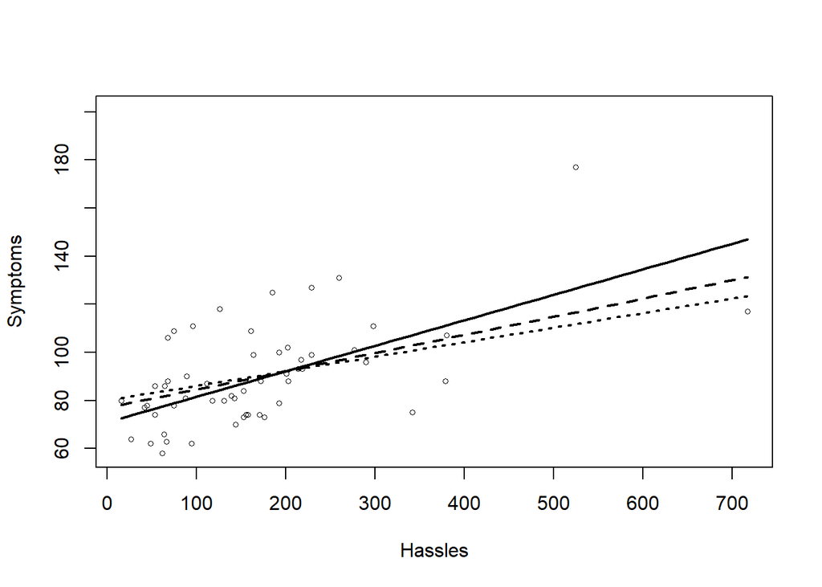

```r
library(rockchalk)
plotSlopes(sympmod1,
           plotx = "hassles",
           modx = "support",
           legendTitle = 'Percentile of Social support',
           legendArgs = list(x = 300, y = 300, title = ""),
           col = c('black', 'black', 'black'),
           xlab = 'Hassles',
           ylab = 'Symptoms',
           data = hass)
```

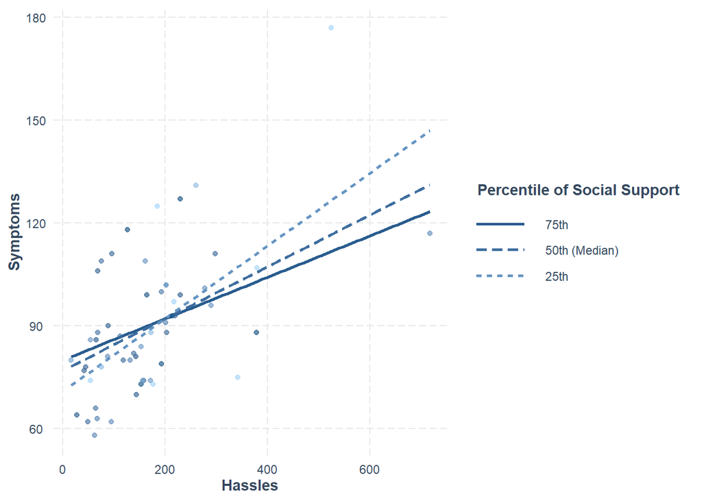

```r
library(interactions)

support_vals <- unique(quantile(hass$support, probs = c(0.25, 0.5, 0.75), na.rm = TRUE))

interact_plot(sympmod1,
              pred = hassles,
              modx = support,
              modx.values = support_vals,
              modx.labels = c("25th", "50th (Median)", "75th"),
              plot.points = TRUE,
              interval = FALSE,
              x.label = "Hassles",
              y.label = "Symptoms",
              legend.main = "Percentile of Social Support")
```

### Assessing Regression Assumptions

The index plot of Cook’s distance reveals a case with extreme influence!

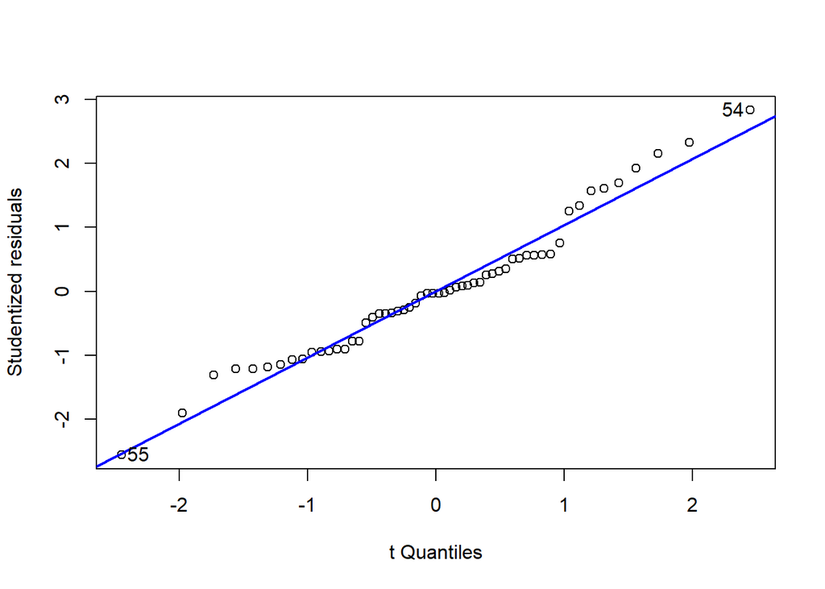

```
[1] 54 55
```

```r
#Distribution of Studentized residuals, using qqPlot() function of the car package
qqPlot(sympmod1, envelope = F, ylab = "Studentized residuals", grid=F)
```

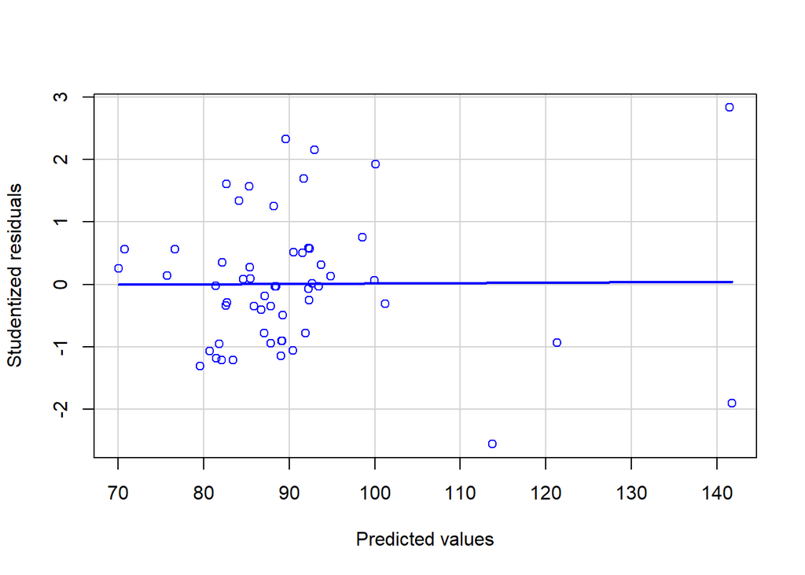

```r
#Residuals vs. Fitted Values Plot
scatterplot(rstudent(sympmod1)~fitted(sympmod1), boxplots=F, ylab='Studentized residuals',
            xlab='Predicted values', smooth=F)
```

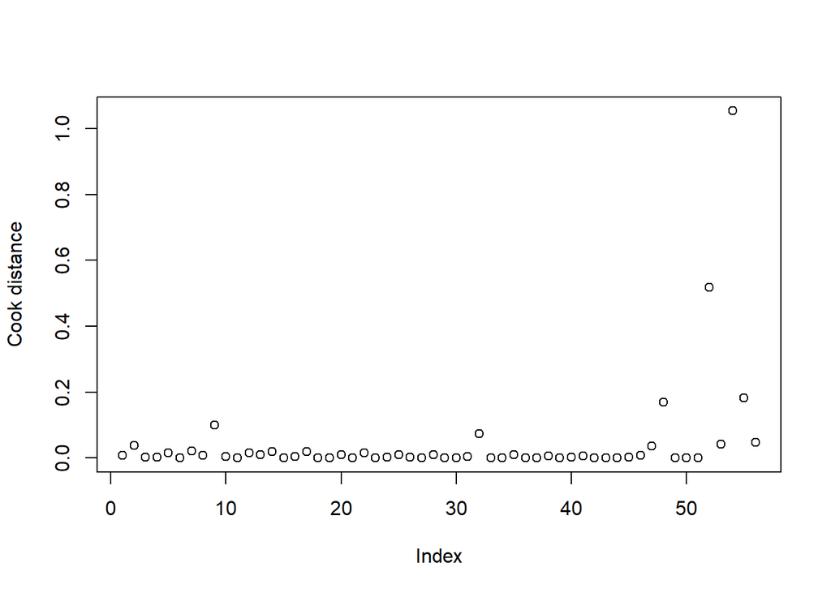

```r
#Cooks Distance Plot
plot(cooks.distance(sympmod1), ylab='Cook distance')
```

```r
#Cooks Distance values for each observation sorted from largest to smallest
sort(cooks.distance(sympmod1), decreasing = TRUE)
```

```
          54           52           55           48            9           32
1.053466e+00 5.175062e-01 1.821190e-01 1.696378e-01 1.006684e-01 7.335830e-02
          56           53            2           47            7           14
4.781160e-02 4.158172e-02 3.733510e-02 3.567516e-02 2.167828e-02 1.991079e-02
          17            5           22           12           20           25
1.959047e-02 1.558736e-02 1.505887e-02 1.449136e-02 1.045591e-02 1.016296e-02
          13           35           28           46            8            1
9.030910e-03 8.935929e-03 8.834625e-03 8.608435e-03 8.013929e-03 7.428188e-03
          38           41           31           10           16           45
5.395774e-03 5.188499e-03 4.291811e-03 4.024500e-03 3.437461e-03 2.574850e-03
          26           24           40            3            4           39
2.559658e-03 2.235056e-03 1.847739e-03 1.846967e-03 1.302932e-03 1.268728e-03
          21           11           37           51           15           29
1.131005e-03 1.049423e-03 9.691003e-04 9.423725e-04 7.733213e-04 6.654720e-04
          30           19           36           50           27           34
6.570478e-04 4.581967e-04 4.330446e-04 3.354443e-04 2.766465e-04 2.433748e-04
           6           23           49           43           44           42
1.018359e-04 4.858416e-05 3.524557e-05 2.774827e-05 1.180483e-05 5.298617e-06
          33           18
4.955075e-06 4.715336e-06
```

We found that case 54 has a large Cook’s distance. We can refit the model without this observation.

```r
#We can view case 54 by referencing the row number in square brackets after the data frame name:
hass[54,]
```

```
   hassles support symptoms suppL suppM suppH
54     525      16      177    -9   -15   -18
```

It looks like the symptoms value for this case is quite high (177). We can refit the model without this case and assess the results.

```r
#Create a new data frame that includes only cases with symptoms < 177, which effectively removes case #54:
hass2 <- subset(hass, symptoms < 177)

# Refit the model without case #54
sympmodr <- lm(symptoms~hassles+support+(hassles*support), data=hass2)
summary(sympmodr)
```

```
Call:
lm(formula = symptoms ~ hassles + support + (hassles * support),
    data = hass2)

Residuals:
    Min      1Q  Median      3Q     Max
-28.375 -12.587  -1.797   5.939  36.634

Coefficients:
                 Estimate Std. Error t value Pr(>|t|)
(Intercept)     65.264594  17.704000   3.686 0.000552 ***
hassles          0.118839   0.074024   1.605 0.114579
support          0.407644   0.592114   0.688 0.494286
hassles:support -0.001655   0.002524  -0.656 0.515015
---
Signif. codes:  0 '***' 0.001 '**' 0.01 '*' 0.05 '.' 0.1 ' ' 1

Residual standard error: 15.86 on 51 degrees of freedom
Multiple R-squared:  0.2291,    Adjusted R-squared:  0.1838
F-statistic: 5.053 on 3 and 51 DF,  p-value: 0.00385
```

```r
#The interaction is no longer significant!
#Case 54 was indeed influential.
```